# ML_YDM

Yakovlev D.M.

2024-11-11

[figure not shown]

# Методы машинного обучения и их применение (в R).

While tidymodels in particular makes it very easy to perform simple ML tasks, mlr3 is more geared towards advanced ML.

На основе датасета из Kaggle (Spaceship Titanic): train.csv - Personal records for about two-thirds (~8700) of the passengers, to be used as training data.

PassengerId - A unique Id for each passenger. Each Id takes the form gggg_pp where gggg indicates a group the passenger is travelling with and pp is their number within the group. People in a group are often family members, but not always.

HomePlanet - The planet the passenger departed from, typically their planet of permanent residence.

CryoSleep - Indicates whether the passenger elected to be put into suspended animation for the duration of the voyage. Passengers in cryosleep are confined to their cabins.

Cabin - The cabin number where the passenger is staying. Takes the form deck/num/side, where side can be either P for Port or S for Starboard.

Destination - The planet the passenger will be debarking to.

Age - The age of the passenger.

VIP - Whether the passenger has paid for special VIP service during the voyage.

RoomService, FoodCourt, ShoppingMall, Spa, VRDeck - Amount the passenger has billed at each of the Spaceship Titanic’s many luxury amenities.

Name - The first and last names of the passenger.

Transported - Whether the passenger was transported to another dimension. This is the target, the column you are trying to predict.

### 0. Подготовительный этап, EDA.

Рассмотрим нашу задачу: необходимо смоделировать Transported в зависимости от каждого признака (кроме, разве что, PassengerId и Name). Для этого, при необходимости, конвертируем типы в нужные нам типы.

```r
library(mlr3verse)
library(tidyverse)
dt<-read.csv("spaceship-titanic\\train.csv")
summary(dt)
```

```
##  PassengerId         HomePlanet         CryoSleep            Cabin
##  Length:8693        Length:8693        Length:8693        Length:8693
##  Class :character   Class :character   Class :character   Class :character
##  Mode  :character   Mode  :character   Mode  :character   Mode  :character
##
##
##
##
##  Destination             Age            VIP             RoomService
##  Length:8693        Min.   : 0.00   Length:8693        Min.   :    0.0
##  Class :character   1st Qu.:19.00   Class :character   1st Qu.:    0.0
##  Mode  :character   Median :27.00   Mode  :character   Median :    0.0
##                     Mean   :28.83                      Mean   :  224.7
##                     3rd Qu.:38.00                      3rd Qu.:   47.0
##                     Max.   :79.00                      Max.   :14327.0
##                     NA's   :179                        NA's   :181
##    FoodCourt        ShoppingMall          Spa              VRDeck
##  Min.   :    0.0   Min.   :    0.0   Min.   :    0.0   Min.   :    0.0
##  1st Qu.:    0.0   1st Qu.:    0.0   1st Qu.:    0.0   1st Qu.:    0.0
##  Median :    0.0   Median :    0.0   Median :    0.0   Median :    0.0
##  Mean   :  458.1   Mean   :  173.7   Mean   :  311.1   Mean   :  304.9
##  3rd Qu.:   76.0   3rd Qu.:   27.0   3rd Qu.:   59.0   3rd Qu.:   46.0
##  Max.   :29813.0   Max.   :23492.0   Max.   :22408.0   Max.   :24133.0
##  NA's   :183       NA's   :208       NA's   :183       NA's   :188
##      Name           Transported
##  Length:8693        Length:8693
##  Class :character   Class :character
##  Mode  :character   Mode  :character
##
##
##
##
```

```r
head(dt)
```

```
##   PassengerId HomePlanet CryoSleep Cabin   Destination Age   VIP RoomService
## 1     0001_01     Europa     False B/0/P   TRAPPIST-1e  39 False           0
## 2     0002_01      Earth     False F/0/S   TRAPPIST-1e  24 False         109
## 3     0003_01     Europa     False A/0/S   TRAPPIST-1e  58  True          43
## 4     0003_02     Europa     False A/0/S   TRAPPIST-1e  33 False           0
## 5     0004_01      Earth     False F/1/S   TRAPPIST-1e  16 False         303
## 6     0005_01      Earth     False F/0/P PSO J318.5-22  44 False           0
##   FoodCourt ShoppingMall  Spa VRDeck              Name Transported
## 1         0            0    0      0   Maham Ofracculy       False
## 2         9           25  549     44      Juanna Vines        True
## 3      3576            0 6715     49     Altark Susent       False
## 4      1283          371 3329    193      Solam Susent       False
## 5        70          151  565      2 Willy Santantines        True
## 6       483            0  291      0 Sandie Hinetthews        True
```

```r
dt_modified<-dt
```

```r
dt_modified$CryoSleep<-as.integer(as.logical(dt_modified$CryoSleep))
dt_modified$VIP<-as.integer(as.logical(dt_modified$VIP))
for(i in 1:length(dt_modified)){
  if((is.character(dt_modified[,i]) && (names(dt_modified)[i]!="Transported"))){
    dt_modified[,i]<-match(dt_modified[,i], levels(factor(dt_modified[,i])))-1
  }
}
# for(i in 1:length(dt_modified)){
#   if((is.character(dt_modified[,i]) && (names(dt_modified)[i]!="Transported"))){
#     dt_modified[,i]<-as.factor(dt_modified[,i])
#   }
# }
# dt_modified<-dt_modified[-c(1,(length(dt_modified)-1))]
str(dt_modified)
```

```
## 'data.frame':    8693 obs. of  14 variables:
##  $ PassengerId : num  0 1 2 3 4 5 6 7 8 9 ...
##  $ HomePlanet  : num  2 1 2 2 1 1 1 1 1 2 ...
##  $ CryoSleep   : int  0 0 0 0 0 0 0 1 0 1 ...
##  $ Cabin       : num  150 2185 2 2 2187 ...
##  $ Destination : num  3 3 3 3 3 2 3 3 3 1 ...
##  $ Age         : num  39 24 58 33 16 44 26 28 35 14 ...
##  $ VIP         : int  0 0 1 0 0 0 0 0 0 0 ...
##  $ RoomService : num  0 109 43 0 303 0 42 0 0 0 ...
##  $ FoodCourt   : num  0 9 3576 1283 70 ...
##  $ ShoppingMall: num  0 25 0 371 151 0 3 0 17 0 ...
##  $ Spa         : num  0 549 6715 3329 565 ...
##  $ VRDeck      : num  0 44 49 193 2 0 0 NA 0 0 ...
##  $ Name        : num  5253 4503 458 7150 8320 ...
##  $ Transported : chr  "False" "True" "False" "False" ...
```

```r
summary(dt_modified)
```

```
##   PassengerId     HomePlanet      CryoSleep          Cabin       Destination
##  Min.   :   0   Min.   :0.000   Min.   :0.0000   Min.   :   0   Min.   :0.000
##  1st Qu.:2173   1st Qu.:1.000   1st Qu.:0.0000   1st Qu.:1185   1st Qu.:2.000
##  Median :4346   Median :1.000   Median :0.0000   Median :3045   Median :3.000
##  Mean   :4346   Mean   :1.627   Mean   :0.3583   Mean   :3079   Mean   :2.431
##  3rd Qu.:6519   3rd Qu.:2.000   3rd Qu.:1.0000   3rd Qu.:4860   3rd Qu.:3.000
##  Max.   :8692   Max.   :3.000   Max.   :1.0000   Max.   :6560   Max.   :3.000
##                                 NA's   :217
##       Age             VIP           RoomService        FoodCourt
##  Min.   : 0.00   Min.   :0.00000   Min.   :    0.0   Min.   :    0.0
##  1st Qu.:19.00   1st Qu.:0.00000   1st Qu.:    0.0   1st Qu.:    0.0
##  Median :27.00   Median :0.00000   Median :    0.0   Median :    0.0
##  Mean   :28.83   Mean   :0.02344   Mean   :  224.7   Mean   :  458.1
##  3rd Qu.:38.00   3rd Qu.:0.00000   3rd Qu.:   47.0   3rd Qu.:   76.0
##  Max.   :79.00   Max.   :1.00000   Max.   :14327.0   Max.   :29813.0
##  NA's   :179     NA's   :203       NA's   :181       NA's   :183
##   ShoppingMall          Spa              VRDeck             Name
##  Min.   :    0.0   Min.   :    0.0   Min.   :    0.0   Min.   :   0
##  1st Qu.:    0.0   1st Qu.:    0.0   1st Qu.:    0.0   1st Qu.:1968
##  Median :    0.0   Median :    0.0   Median :    0.0   Median :4133
##  Mean   :  173.7   Mean   :  311.1   Mean   :  304.9   Mean   :4137
##  3rd Qu.:   27.0   3rd Qu.:   59.0   3rd Qu.:   46.0   3rd Qu.:6303
##  Max.   :23492.0   Max.   :22408.0   Max.   :24133.0   Max.   :8473
##  NA's   :208       NA's   :183       NA's   :188
##  Transported
##  Length:8693
##  Class :character
##  Mode  :character
##
##
##
##
```

```r
dt_modified<-dt_modified|>drop_na()
summary(dt_modified)
```

```
##   PassengerId     HomePlanet      CryoSleep          Cabin       Destination
##  Min.   :   0   Min.   :0.000   Min.   :0.0000   Min.   :   0   Min.   :0.000
##  1st Qu.:2200   1st Qu.:1.000   1st Qu.:0.0000   1st Qu.:1160   1st Qu.:2.000
##  Median :4359   Median :1.000   Median :0.0000   Median :3030   Median :3.000
##  Mean   :4362   Mean   :1.626   Mean   :0.3518   Mean   :3063   Mean   :2.428
##  3rd Qu.:6542   3rd Qu.:2.000   3rd Qu.:1.0000   3rd Qu.:4836   3rd Qu.:3.000
##  Max.   :8692   Max.   :3.000   Max.   :1.0000   Max.   :6560   Max.   :3.000
##       Age             VIP           RoomService        FoodCourt
##  Min.   : 0.00   Min.   :0.00000   Min.   :    0.0   Min.   :    0.0
##  1st Qu.:19.00   1st Qu.:0.00000   1st Qu.:    0.0   1st Qu.:    0.0
##  Median :27.00   Median :0.00000   Median :    0.0   Median :    0.0
##  Mean   :28.93   Mean   :0.02427   Mean   :  225.8   Mean   :  472.7
##  3rd Qu.:38.00   3rd Qu.:0.00000   3rd Qu.:   49.0   3rd Qu.:   80.0
##  Max.   :79.00   Max.   :1.00000   Max.   :14327.0   Max.   :29813.0
##   ShoppingMall          Spa            VRDeck             Name
##  Min.   :    0.0   Min.   :    0   Min.   :    0.0   Min.   :   0
##  1st Qu.:    0.0   1st Qu.:    0   1st Qu.:    0.0   1st Qu.:1960
##  Median :    0.0   Median :    0   Median :    0.0   Median :4147
##  Mean   :  177.2   Mean   :  318   Mean   :  302.5   Mean   :4145
##  3rd Qu.:   29.0   3rd Qu.:   65   3rd Qu.:   52.0   3rd Qu.:6326
##  Max.   :23492.0   Max.   :22408   Max.   :20336.0   Max.   :8473
##  Transported
##  Length:7251
##  Class :character
##  Mode  :character
##
##
##
```

```r
dim(dt)
```

```
## [1] 8693   14
```

```r
dim(dt_modified)
```

```
## [1] 7251   14
```

```r
tsk_spt<-as_task_classif(dt_modified, target="Transported", id="ClassifTask", positive="True")
tsk_spt$set_col_roles(c("HomePlanet", "CryoSleep", "VIP", "Destination"), "stratum")
names(dt_modified)
```

```
##  [1] "PassengerId"  "HomePlanet"   "CryoSleep"    "Cabin"        "Destination"
##  [6] "Age"          "VIP"          "RoomService"  "FoodCourt"    "ShoppingMall"
## [11] "Spa"          "VRDeck"       "Name"         "Transported"
```

```r
# tsk_spt$select(c("HomePlanet", "CryoSleep", "Destination", "Age", "VIP", "RoomService", "FoodCourt", "ShoppingMall", "Spa", "VRDeck"))
tsk_spt$select(c("Age", "RoomService", "FoodCourt", "ShoppingMall", "Spa", "VRDeck"))
tsk_spt
```

```
## <TaskClassif:ClassifTask> (7251 x 7)
## * Target: Transported
## * Properties: twoclass, strata
## * Features (6):
##   - dbl (6): Age, FoodCourt, RoomService, ShoppingMall, Spa, VRDeck
## * Strata: HomePlanet, CryoSleep, VIP, Destination
```

Resample

```r
as.data.table(rsmps())
```

```
## Key: <key>
##            key                         label        params iters
##         <char>                        <char>        <list> <int>
## 1:   bootstrap                     Bootstrap ratio,repeats    30
## 2:      custom                 Custom Splits                  NA
## 3:   custom_cv Custom Split Cross-Validation                  NA
## 4:          cv              Cross-Validation         folds    10
## 5:     holdout                       Holdout         ratio     1
## 6:    insample           Insample Resampling                   1
## 7:         loo                 Leave-One-Out                  NA
## 8: repeated_cv     Repeated Cross-Validation folds,repeats   100
## 9: subsampling                   Subsampling ratio,repeats    30
```

```r
holdout = rsmp("holdout", ratio = 0.8)
cv3 = rsmp("cv", folds = 3)
```

Measures

```r
as.data.table(msrs())
```

```
## Key: <key>
##                      key                                               label
##                   <char>                                              <char>
##  1:                  aic                        Akaike Information Criterion
##  2:                  bic                      Bayesian Information Criterion
##  3:          classif.acc                             Classification Accuracy
##  4:          classif.auc                            Area Under the ROC Curve
##  5:         classif.bacc                                   Balanced Accuracy
##  6:       classif.bbrier                                  Binary Brier Score
##  7:           classif.ce                                Classification Error
##  8:        classif.costs                       Cost-sensitive Classification
##  9:          classif.dor                               Diagnostic Odds Ratio
## 10:        classif.fbeta                                        F-beta score
## 11:          classif.fdr                                False Discovery Rate
## 12:           classif.fn                                     False Negatives
## 13:          classif.fnr                                 False Negative Rate
## 14:         classif.fomr                                 False Omission Rate
## 15:           classif.fp                                     False Positives
## 16:          classif.fpr                                 False Positive Rate
## 17:      classif.logloss                                            Log Loss
## 18:    classif.mauc_au1p             Weighted average 1 vs. 1 multiclass AUC
## 19:    classif.mauc_au1u                      Average 1 vs. 1 multiclass AUC
## 20:    classif.mauc_aunp          Weighted average 1 vs. rest multiclass AUC
## 21:    classif.mauc_aunu                   Average 1 vs. rest multiclass AUC
## 22:      classif.mauc_mu                                   Multiclass mu AUC
## 23:       classif.mbrier                              Multiclass Brier Score
## 24:          classif.mcc                    Matthews Correlation Coefficient
## 25:          classif.npv                           Negative Predictive Value
## 26:          classif.ppv                           Positive Predictive Value
## 27:        classif.prauc                              Precision-Recall Curve
## 28:    classif.precision                                           Precision
## 29:       classif.recall                                              Recall
## 30:  classif.sensitivity                                         Sensitivity
## 31:  classif.specificity                                         Specificity
## 32:           classif.tn                                      True Negatives
## 33:          classif.tnr                                  True Negative Rate
## 34:           classif.tp                                      True Positives
## 35:          classif.tpr                                  True Positive Rate
## 36:             clust.ch                                   Calinski Harabasz
## 37:           clust.dunn                                                Dunn
```

[output cut: 234 more lines]

```
## 56:
## 57:
## 58:
## 59:
## 60:
## 61:
## 62:
## 63:
## 64:
## 65:
## 66:
## 67:
## 68:
## 69:
##     task_properties
```

Benchmark

```r
lrn("classif.kknn")$param_set
```

```
## <ParamSet(6)>
##             id    class lower upper nlevels default  value
##         <char>   <char> <num> <num>   <num>  <list> <list>
## 1:           k ParamInt     1   Inf     Inf       7      7
## 2:    distance ParamDbl     0   Inf     Inf       2 [NULL]
## 3:      kernel ParamFct    NA    NA      10 optimal [NULL]
## 4:       scale ParamLgl    NA    NA       2    TRUE [NULL]
## 5:     ykernel ParamUty    NA    NA     Inf  [NULL] [NULL]
## 6: store_model ParamLgl    NA    NA       2   FALSE [NULL]
```

```r
lrn("classif.kknn")$param_set$default
```

```
## $k
## [1] 7
##
## $distance
## [1] 2
##
## $kernel
## [1] "optimal"
##
## $scale
## [1] TRUE
##
## $ykernel
## NULL
##
## $store_model
## [1] FALSE
```

```r
lrn("classif.ranger")$param_set
```

```
## <ParamSet(27)>
## Key: <id>
##                               id    class lower upper nlevels        default
##                           <char>   <char> <num> <num>   <num>         <list>
##  1:       always.split.variables ParamUty    NA    NA     Inf <NoDefault[0]>
##  2:                class.weights ParamUty    NA    NA     Inf         [NULL]
##  3:                      holdout ParamLgl    NA    NA       2          FALSE
##  4:                   importance ParamFct    NA    NA       4 <NoDefault[0]>
##  5:                   keep.inbag ParamLgl    NA    NA       2          FALSE
##  6:                    max.depth ParamInt     1   Inf     Inf         [NULL]
##  7:                   min.bucket ParamInt     1   Inf     Inf              1
##  8:                min.node.size ParamInt     1   Inf     Inf         [NULL]
##  9:                         mtry ParamInt     1   Inf     Inf <NoDefault[0]>
## 10:                   mtry.ratio ParamDbl     0     1     Inf <NoDefault[0]>
## 11:                   node.stats ParamLgl    NA    NA       2          FALSE
```

[output cut: 47 more lines]

```r
lrn("classif.ranger")$param_set$default
```

```
## $class.weights
## NULL
##
## $holdout
## [1] FALSE
##
## $keep.inbag
## [1] FALSE
##
## $max.depth
## NULL
##
## $min.bucket
## [1] 1
##
## $min.node.size
## NULL
##
## $num.random.splits
## [1] 1
##
## $node.stats
## [1] FALSE
##
## $num.threads
## [1] 1
##
## $num.trees
## [1] 500
##
## $oob.error
## [1] TRUE
##
## $regularization.factor
## [1] 1
##
## $regularization.usedepth
## [1] FALSE
##
## $replace
## [1] TRUE
##
## $save.memory
## [1] FALSE
##
## $scale.permutation.importance
## [1] FALSE
##
## $seed
## NULL
##
## $split.select.weights
## NULL
##
## $splitrule
## [1] "gini"
##
## $verbose
## [1] TRUE
##
## $write.forest
## [1] TRUE
```

```r
lrn("classif.featureless")$param_set
```

```
## <ParamSet(1)>
##        id    class lower upper nlevels default  value
##    <char>   <char> <num> <num>   <num>  <list> <list>
## 1: method ParamFct    NA    NA       3    mode   mode
```

```r
lrn("classif.featureless")$param_set$default
```

```
## $method
## [1] "mode"
```

```r
lrn("classif.svm")$param_set
```

```
## <ParamSet(16)>
## Key: <id>
##                  id    class lower upper nlevels          default parents
##              <char>   <char> <num> <num>   <num>           <list>  <list>
##  1:       cachesize ParamDbl  -Inf   Inf     Inf               40  [NULL]
##  2:   class.weights ParamUty    NA    NA     Inf           [NULL]  [NULL]
##  3:           coef0 ParamDbl  -Inf   Inf     Inf                0  kernel
##  4:            cost ParamDbl     0   Inf     Inf                1    type
##  5:           cross ParamInt     0   Inf     Inf                0  [NULL]
##  6: decision.values ParamLgl    NA    NA       2            FALSE  [NULL]
##  7:          degree ParamInt     1   Inf     Inf                3  kernel
##  8:         epsilon ParamDbl     0   Inf     Inf              0.1  [NULL]
##  9:          fitted ParamLgl    NA    NA       2             TRUE  [NULL]
## 10:           gamma ParamDbl     0   Inf     Inf   <NoDefault[0]>  kernel
## 11:          kernel ParamFct    NA    NA       4           radial  [NULL]
```

[output cut: 23 more lines]

```r
lrn("classif.svm")$param_set$default
```

```
## $cachesize
## [1] 40
##
## $class.weights
## NULL
##
## $coef0
## [1] 0
##
## $cost
## [1] 1
##
## $cross
## [1] 0
##
## $decision.values
## [1] FALSE
##
## $degree
## [1] 3
##
## $epsilon
## [1] 0.1
##
## $fitted
## [1] TRUE
##
## $kernel
## [1] "radial"
##
## $nu
## [1] 0.5
##
## $scale
## [1] TRUE
##
## $shrinking
## [1] TRUE
##
## $tolerance
## [1] 0.001
##
## $type
## [1] "C-classification"
```

```r
design=benchmark_grid(
  tasks = tsk_spt,
  learners = lrns(c("classif.kknn", "classif.ranger", "classif.featureless", "classif.log_reg", "classif.svm"), predict_type="prob"),
  resamplings = c(holdout, cv3)
)
as.data.table(lrns())
```

```
## Key: <key>
##                     key                                 label task_type
##                  <char>                                <char>    <char>
##  1:   classif.cv_glmnet   GLM with Elastic Net Regularization   classif
##  2:       classif.debug      Debug Learner for Classification   classif
##  3: classif.featureless    Featureless Classification Learner   classif
##  4:      classif.glmnet   GLM with Elastic Net Regularization   classif
##  5:        classif.kknn                    k-Nearest-Neighbor   classif
##  6:         classif.lda          Linear Discriminant Analysis   classif
##  7:     classif.log_reg                   Logistic Regression   classif
##  8:    classif.multinom          Multinomial Log-Linear Model   classif
##  9: classif.naive_bayes                           Naive Bayes   classif
## 10:        classif.nnet           Single Layer Neural Network   classif
## 11:         classif.qda       Quadratic Discriminant Analysis   classif
## 12:      classif.ranger                         Random Forest   classif
```

[output cut: 256 more lines]

```r
library(e1071)
bmr = benchmark(design)
```

[output not shown]

```
## INFO  [12:37:37.621] [mlr3] Finished benchmark
```

```r
bmr
```

```
## <BenchmarkResult> of 20 rows with 10 resampling runs
##  nr     task_id          learner_id resampling_id iters warnings errors
##   1 ClassifTask        classif.kknn       holdout     1        0      0
##   2 ClassifTask        classif.kknn            cv     3        0      0
##   3 ClassifTask      classif.ranger       holdout     1        0      0
##   4 ClassifTask      classif.ranger            cv     3        0      0
##   5 ClassifTask classif.featureless       holdout     1        0      0
##   6 ClassifTask classif.featureless            cv     3        0      0
##   7 ClassifTask     classif.log_reg       holdout     1        0      0
##   8 ClassifTask     classif.log_reg            cv     3        0      0
##   9 ClassifTask         classif.svm       holdout     1        0      0
##  10 ClassifTask         classif.svm            cv     3        0      0
```

```r
bmr$score(msr("classif.acc"))[, .(iteration, task_id, learner_id, classif.acc)]
```

```
##     iteration     task_id          learner_id classif.acc
##         <int>      <char>              <char>       <num>
##  1:         1 ClassifTask        classif.kknn   0.7236389
##  2:         1 ClassifTask        classif.kknn   0.7468094
##  3:         2 ClassifTask        classif.kknn   0.7555739
##  4:         3 ClassifTask        classif.kknn   0.7454167
##  5:         1 ClassifTask      classif.ranger   0.7946244
##  6:         1 ClassifTask      classif.ranger   0.7900371
##  7:         2 ClassifTask      classif.ranger   0.7989265
##  8:         3 ClassifTask      classif.ranger   0.7841667
##  9:         1 ClassifTask classif.featureless   0.4748449
## 10:         1 ClassifTask classif.featureless   0.5039111
## 11:         2 ClassifTask classif.featureless   0.4938068
## 12:         3 ClassifTask classif.featureless   0.4904167
## 13:         1 ClassifTask     classif.log_reg   0.7849759
## 14:         1 ClassifTask     classif.log_reg   0.7797448
## 15:         2 ClassifTask     classif.log_reg   0.7844756
## 16:         3 ClassifTask     classif.log_reg   0.7770833
## 17:         1 ClassifTask         classif.svm   0.7994487
## 18:         1 ClassifTask         classif.svm   0.7908604
## 19:         2 ClassifTask         classif.svm   0.7993394
## 20:         3 ClassifTask         classif.svm   0.7825000
##     iteration     task_id          learner_id classif.acc
```

```r
bmr$aggregate(msr("classif.acc"))[, .(task_id, learner_id, classif.acc)]
```

```
##         task_id          learner_id classif.acc
##          <char>              <char>       <num>
##  1: ClassifTask        classif.kknn   0.7236389
##  2: ClassifTask        classif.kknn   0.7492667
##  3: ClassifTask      classif.ranger   0.7946244
##  4: ClassifTask      classif.ranger   0.7910434
##  5: ClassifTask classif.featureless   0.4748449
##  6: ClassifTask classif.featureless   0.4960448
##  7: ClassifTask     classif.log_reg   0.7849759
##  8: ClassifTask     classif.log_reg   0.7804346
##  9: ClassifTask         classif.svm   0.7994487
## 10: ClassifTask         classif.svm   0.7908999
```

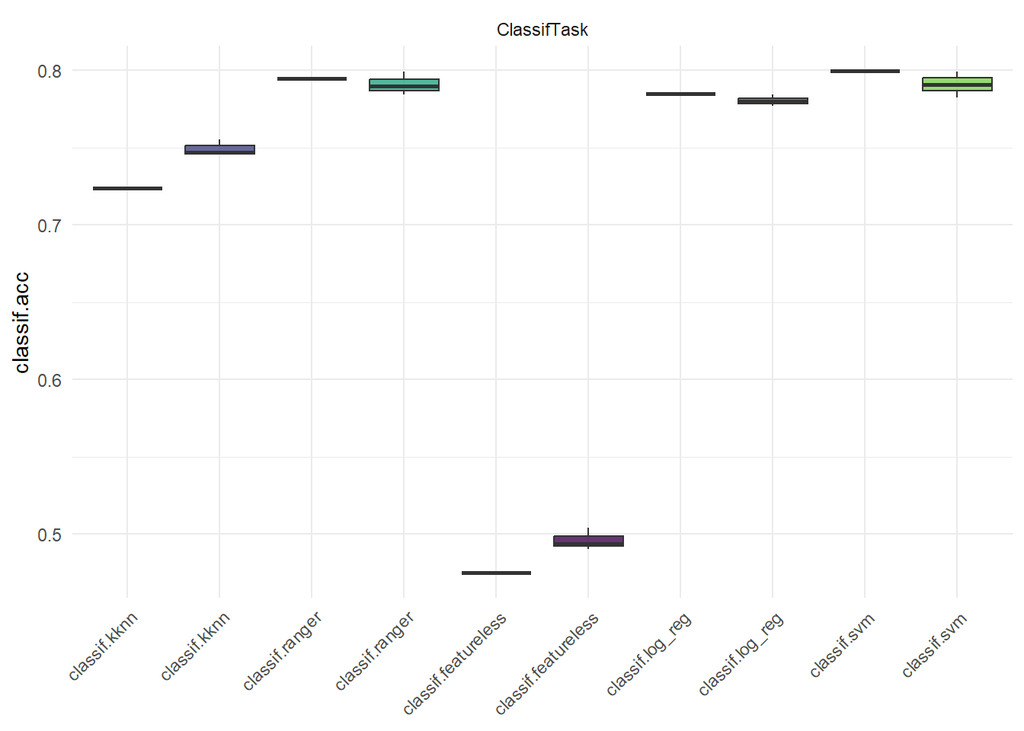

```r
autoplot(bmr, measure = msr("classif.acc"))
```

```r
measures = msrs(c("classif.ce", "classif.tnr", "classif.fnr", "classif.tpr", "classif.fpr", "time_both"))
bmr$aggregate(measures)
```

```
##        nr     task_id          learner_id resampling_id iters classif.ce
##     <int>      <char>              <char>        <char> <int>      <num>
##  1:     1 ClassifTask        classif.kknn       holdout     1  0.2763611
##  2:     2 ClassifTask        classif.kknn            cv     3  0.2507333
##  3:     3 ClassifTask      classif.ranger       holdout     1  0.2053756
##  4:     4 ClassifTask      classif.ranger            cv     3  0.2089566
##  5:     5 ClassifTask classif.featureless       holdout     1  0.5251551
##  6:     6 ClassifTask classif.featureless            cv     3  0.5039552
##  7:     7 ClassifTask     classif.log_reg       holdout     1  0.2150241
##  8:     8 ClassifTask     classif.log_reg            cv     3  0.2195654
##  9:     9 ClassifTask         classif.svm       holdout     1  0.2005513
## 10:    10 ClassifTask         classif.svm            cv     3  0.2091001
##     classif.tnr classif.fnr classif.tpr classif.fpr   time_both
##           <num>       <num>       <num>       <num>       <num>
##  1:   0.6966618  0.25196850   0.7480315   0.3033382 0.110000000
##  2:   0.7250762  0.22660335   0.7733966   0.2749238 0.180000000
##  3:   0.7489115  0.16404199   0.8359580   0.2510885 1.330000000
##  4:   0.7404943  0.15889984   0.8411002   0.2595057 1.290000000
##  5:   1.0000000  1.00000000   0.0000000   0.0000000 0.000000000
##  6:   0.3333333  0.33333333   0.6666667   0.6666667 0.006666667
##  7:   0.6545718  0.09711286   0.9028871   0.3454282 0.050000000
##  8:   0.6687965  0.10893330   0.8910667   0.3312035 0.040000000
##  9:   0.7285922  0.13648294   0.8635171   0.2714078 8.980000000
## 10:   0.7214553  0.14017485   0.8598251   0.2785447 6.563333333
## Hidden columns: resample_result
```

```r
library(mlr3measures)
for(i in 1:length(bmr$resample_results$nr)){
  rr_predict<-bmr$resample_result(i)$prediction()
  print(confusion_matrix(rr_predict$truth, rr_predict$response, rr_predict$positive))
}
```

```
##         truth
## response True False
##    True   570   209
##    False  192   480
## acc :  0.7236; ce  :  0.2764; dor :  6.8182; f1  :  0.7398
## fdr :  0.2683; fnr :  0.2520; fomr:  0.2857; fpr :  0.3033
## mcc :  0.4453; npv :  0.7143; ppv :  0.7317; tnr :  0.6967
## tpr :  0.7480
##         truth
## response True False
##    True  2817   992
##    False  826  2616
## acc :  0.7493; ce  :  0.2507; dor :  8.9936; f1  :  0.7560
## fdr :  0.2604; fnr :  0.2267; fomr:  0.2400; fpr :  0.2749
## mcc :  0.4990; npv :  0.7600; ppv :  0.7396; tnr :  0.7251
## tpr :  0.7733
##         truth
## response True False
##    True   637   173
##    False  125   516
## acc :  0.7946; ce  :  0.2054; dor :  15.1996; f1  :  0.8104
## fdr :  0.2136; fnr :  0.1640; fomr:  0.1950; fpr :  0.2511
## mcc :  0.5881; npv :  0.8050; ppv :  0.7864; tnr :  0.7489
## tpr :  0.8360
##         truth
## response True False
##    True  3064   936
##    False  579  2672
## acc :  0.7911; ce  :  0.2089; dor :  15.1067; f1  :  0.8018
## fdr :  0.2340; fnr :  0.1589; fomr:  0.1781; fpr :  0.2594
## mcc :  0.5848; npv :  0.8219; ppv :  0.7660; tnr :  0.7406
## tpr :  0.8411
##         truth
## response True False
##    True     0     0
##    False  762   689
## acc :  0.4748; ce  :  0.5252; dor :  NaN; f1  :  NaN
## fdr :  NaN; fnr :  1.0000; fomr:  0.5252; fpr :  0.0000
## mcc :  0.0000; npv :  0.4748; ppv :  NaN; tnr :  1.0000
## tpr :  0.0000
```

[output cut: 25 more lines]

```
## response True False
##    True   658   187
##    False  104   502
## acc :  0.7994; ce  :  0.2006; dor :  16.9846; f1  :  0.8189
## fdr :  0.2213; fnr :  0.1365; fomr:  0.1716; fpr :  0.2714
## mcc :  0.5995; npv :  0.8284; ppv :  0.7787; tnr :  0.7286
## tpr :  0.8635
##         truth
## response True False
##    True  3132  1005
##    False  511  2603
## acc :  0.7909; ce  :  0.2091; dor :  15.8748; f1  :  0.8051
## fdr :  0.2429; fnr :  0.1403; fomr:  0.1641; fpr :  0.2785
## mcc :  0.5870; npv :  0.8359; ppv :  0.7571; tnr :  0.7215
## tpr :  0.8597
```

```r
library(patchwork)
bmr
```

```
## <BenchmarkResult> of 20 rows with 10 resampling runs
##  nr     task_id          learner_id resampling_id iters warnings errors
##   1 ClassifTask        classif.kknn       holdout     1        0      0
##   2 ClassifTask        classif.kknn            cv     3        0      0
##   3 ClassifTask      classif.ranger       holdout     1        0      0
##   4 ClassifTask      classif.ranger            cv     3        0      0
##   5 ClassifTask classif.featureless       holdout     1        0      0
##   6 ClassifTask classif.featureless            cv     3        0      0
##   7 ClassifTask     classif.log_reg       holdout     1        0      0
##   8 ClassifTask     classif.log_reg            cv     3        0      0
##   9 ClassifTask         classif.svm       holdout     1        0      0
##  10 ClassifTask         classif.svm            cv     3        0      0
```

```r
bmr_holdout<-bmr$clone(deep=TRUE)
bmr_holdout$filter(resampling_id = "holdout")
bmr_holdout
```

```
## <BenchmarkResult> of 5 rows with 5 resampling runs
##  nr     task_id          learner_id resampling_id iters warnings errors
##   1 ClassifTask        classif.kknn       holdout     1        0      0
##   2 ClassifTask      classif.ranger       holdout     1        0      0
##   3 ClassifTask classif.featureless       holdout     1        0      0
##   4 ClassifTask     classif.log_reg       holdout     1        0      0
##   5 ClassifTask         classif.svm       holdout     1        0      0
```

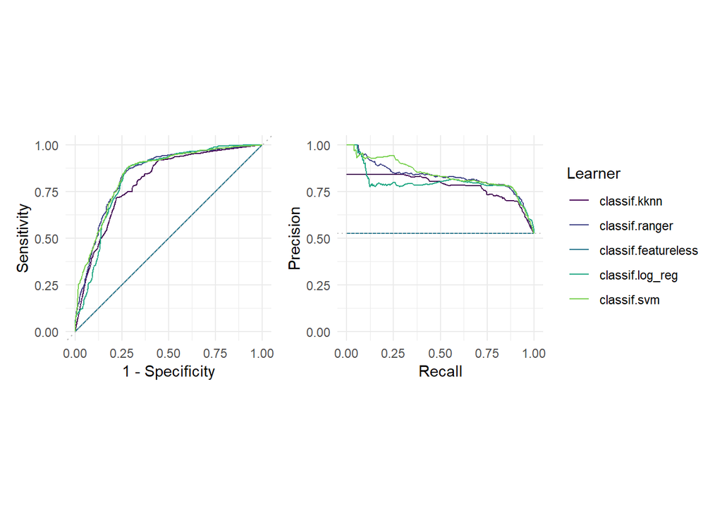

```r
autoplot(bmr_holdout, type="roc")+autoplot(bmr_holdout, type="prc")+
  plot_layout(guides="collect")
```

```r
bmr_cv<-bmr$clone(deep=TRUE)
bmr_cv$filter(resampling_id = "cv")
bmr_cv
```

```
## <BenchmarkResult> of 15 rows with 5 resampling runs
##  nr     task_id          learner_id resampling_id iters warnings errors
##   1 ClassifTask        classif.kknn            cv     3        0      0
##   2 ClassifTask      classif.ranger            cv     3        0      0
##   3 ClassifTask classif.featureless            cv     3        0      0
##   4 ClassifTask     classif.log_reg            cv     3        0      0
##   5 ClassifTask         classif.svm            cv     3        0      0
```

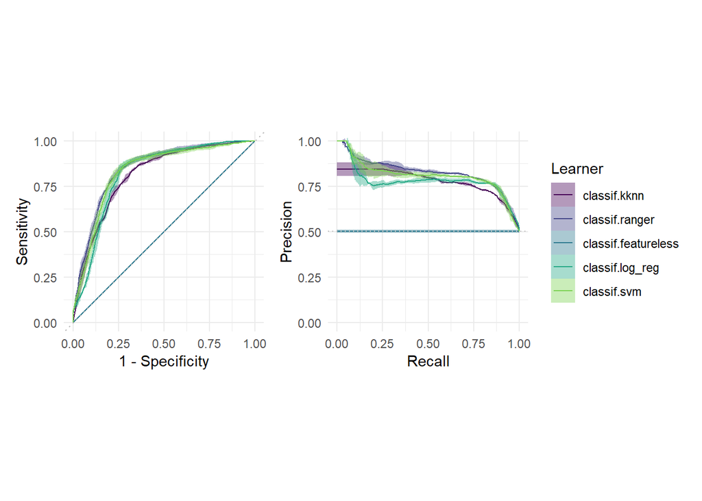

```r
autoplot(bmr_cv, type="roc")+autoplot(bmr_cv, type="prc")+
  plot_layout(guides="collect")
```

Если хотим оптимизировать гиперпараметры:

classif.kknn

```r
lrn("classif.kknn")$param_set$default
```

```
## $k
## [1] 7
##
## $distance
## [1] 2
##
## $kernel
## [1] "optimal"
##
## $scale
## [1] TRUE
##
## $ykernel
## NULL
##
## $store_model
## [1] FALSE
```

```r
learner_kknn = lrn("classif.kknn",
                   k = to_tune(1, 200),
                   distance = to_tune(0.10, 10),
                   scale = TRUE,
                   kernel = "optimal")
```

```r
library(mlr3tuning)
library(mlr3tuningspaces)
instance = ti(
  task = tsk_spt,
  learner = learner_kknn,
  resampling = cv3,
  measures = msr("classif.ce"),
  terminator = trm("none")
)
as.data.table(trms())
```

```
## Key: <key>
##                       key                  label             properties
##                    <char>                 <char>                 <list>
## 1:             clock_time             Clock Time single-crit,multi-crit
## 2:                  combo            Combination single-crit,multi-crit
## 3:                  evals   Number of Evaluation single-crit,multi-crit
## 4:                   none                   None single-crit,multi-crit
## 5:           perf_reached      Performance Level            single-crit
## 6:               run_time               Run Time single-crit,multi-crit
## 7:             stagnation             Stagnation            single-crit
## 8:       stagnation_batch       Stagnation Batch            single-crit
## 9: stagnation_hypervolume Stagnation Hypervolume             multi-crit
##           unit
##         <char>
## 1:     seconds
## 2:     percent
## 3: evaluations
## 4:     percent
## 5:     percent
## 6:     seconds
## 7:     percent
## 8:     percent
## 9:     percent
```

```r
tuner = tnr("grid_search", resolution=5, batch_size=3)
tuner$param_set
```

```
## <ParamSet(3)>
##                   id    class lower upper nlevels        default  value
##               <char>   <char> <num> <num>   <num>         <list> <list>
## 1:        batch_size ParamInt     1   Inf     Inf <NoDefault[0]>      3
## 2:        resolution ParamInt     1   Inf     Inf <NoDefault[0]>      5
## 3: param_resolutions ParamUty    NA    NA     Inf <NoDefault[0]> [NULL]
```

```r
tuner$optimize(instance)
```

[output not shown]

[output cut: 130 more lines]

[output not shown]

```
##        k distance learner_param_vals  x_domain classif.ce
##    <int>    <num>             <list>    <list>      <num>
## 1:    51       10          <list[4]> <list[2]>  0.2166936
```

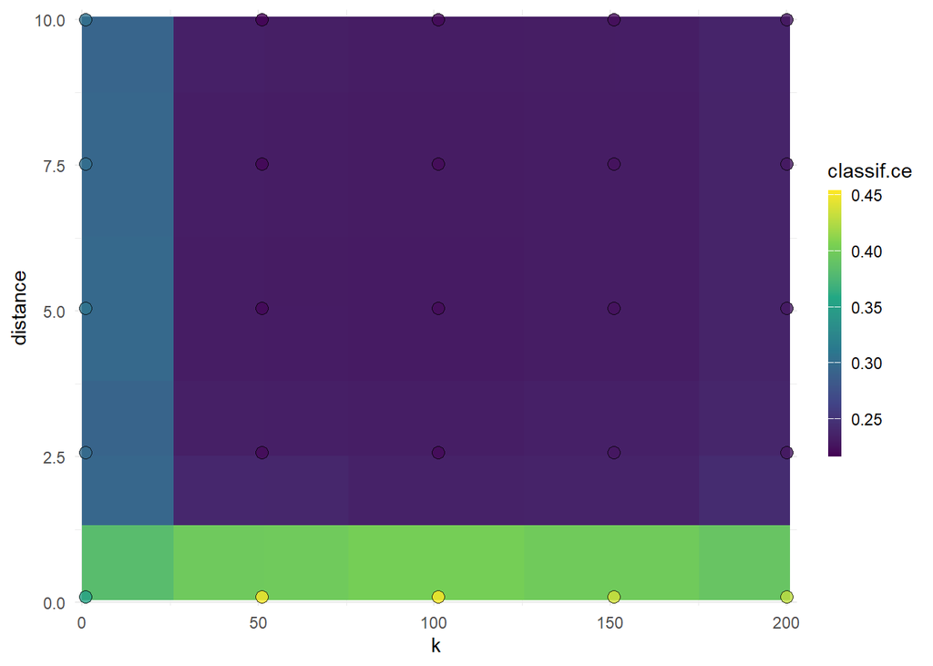

```r
autoplot(instance, type="surface")
```

```r
learner_kknn = lrn("classif.kknn", predict_type="prob")
learner_kknn$param_set$set_values(.values=instance$result_learner_param_vals)
rsmp_kknn = resample(tsk_spt, learner_kknn, cv3)
```

```
## INFO  [12:40:33.250] [mlr3] Applying learner 'classif.kknn' on task 'ClassifTask' (iter 1/3)
## INFO  [12:40:33.948] [mlr3] Applying learner 'classif.kknn' on task 'ClassifTask' (iter 2/3)
## INFO  [12:40:34.661] [mlr3] Applying learner 'classif.kknn' on task 'ClassifTask' (iter 3/3)
```

```r
rsmp_kknn$aggregate(msr("classif.ce"))
```

```
## classif.ce
##  0.2152686
```

```r
bmr_1=as_benchmark_result(rsmp_kknn)
bmr_2=as_benchmark_result(bmr_cv$resample_result(1))
bmr_kknn<-c(bmr_1, bmr_2)
bmr_kknn$aggregate(measures)
```

```
##       nr     task_id   learner_id resampling_id iters classif.ce classif.tnr
##    <int>      <char>       <char>        <char> <int>      <num>       <num>
## 1:     1 ClassifTask classif.kknn            cv     3  0.2152686   0.7196473
## 2:     2 ClassifTask classif.kknn            cv     3  0.2507333   0.7250762
##    classif.fnr classif.tpr classif.fpr time_both
##          <num>       <num>       <num>     <num>
## 1:   0.1506828   0.8493172   0.2803527      0.69
## 2:   0.2266034   0.7733966   0.2749238      0.18
## Hidden columns: resample_result
```

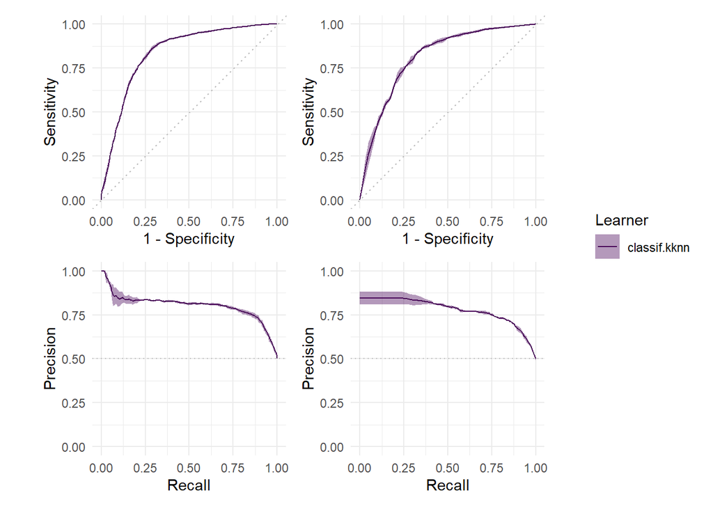

```r
(autoplot(bmr_1, type='roc')+autoplot(bmr_2, type='roc'))/(autoplot(bmr_1,type='prc')+autoplot(bmr_2, type='prc'))+plot_layout(guides="collect")
```

### Интерпретация результатов

```r
bmr$aggregate(measures)
```

```
##        nr     task_id          learner_id resampling_id iters classif.ce
##     <int>      <char>              <char>        <char> <int>      <num>
##  1:     1 ClassifTask        classif.kknn       holdout     1  0.2763611
##  2:     2 ClassifTask        classif.kknn            cv     3  0.2507333
##  3:     3 ClassifTask      classif.ranger       holdout     1  0.2053756
##  4:     4 ClassifTask      classif.ranger            cv     3  0.2089566
##  5:     5 ClassifTask classif.featureless       holdout     1  0.5251551
##  6:     6 ClassifTask classif.featureless            cv     3  0.5039552
##  7:     7 ClassifTask     classif.log_reg       holdout     1  0.2150241
##  8:     8 ClassifTask     classif.log_reg            cv     3  0.2195654
##  9:     9 ClassifTask         classif.svm       holdout     1  0.2005513
## 10:    10 ClassifTask         classif.svm            cv     3  0.2091001
##     classif.tnr classif.fnr classif.tpr classif.fpr   time_both
##           <num>       <num>       <num>       <num>       <num>
##  1:   0.6966618  0.25196850   0.7480315   0.3033382 0.110000000
##  2:   0.7250762  0.22660335   0.7733966   0.2749238 0.180000000
##  3:   0.7489115  0.16404199   0.8359580   0.2510885 1.330000000
##  4:   0.7404943  0.15889984   0.8411002   0.2595057 1.290000000
##  5:   1.0000000  1.00000000   0.0000000   0.0000000 0.000000000
##  6:   0.3333333  0.33333333   0.6666667   0.6666667 0.006666667
##  7:   0.6545718  0.09711286   0.9028871   0.3454282 0.050000000
##  8:   0.6687965  0.10893330   0.8910667   0.3312035 0.040000000
##  9:   0.7285922  0.13648294   0.8635171   0.2714078 8.980000000
## 10:   0.7214553  0.14017485   0.8598251   0.2785447 6.563333333
## Hidden columns: resample_result
```

Лучше всех проявила себя модель classif.svm при holdout (ratio=0.8)

```r
rr_svm=bmr$resample_result(9)
rr_svm
```

```
## <ResampleResult> with 1 resampling iterations
##      task_id  learner_id resampling_id iteration     prediction_test warnings
##  ClassifTask classif.svm       holdout         1 <PredictionClassif>        0
##  errors
##       0
```

```r
pred_svm = rr_svm$prediction()

cor_svm = pred_svm$row_ids[pred_svm$truth==pred_svm$response]
incor_svm = pred_svm$row_ids[pred_svm$truth!=pred_svm$response]
cor_svm
```

```
##    [1]   34  146  203  246  401  412  439  486  683  721  722  901 1116 1151
##   [15] 1153 1201 1241 1270 1323 1514 1624 1681 1710 1781 2054 2056 2190 2222
##   [29] 2256 2279 2649 2665 2682 2956 3010 3209 3309 3324 3384 3401 3408 3467
##   [43] 3527 3583 3585 3590 3629 3650 3674 3713 3948 3965 4136 4173 4175 4177
##   [57] 4277 4336 4423 4500 4629 4734 4807 4955 4980 5051 5116 5130 5165 5216
##   [71] 5276 5291 5293 5428 5444 5482 5516 5541 5588 5657 5658 5677 5680 5752
##   [85] 5758 5785 5893 6013 6171 6349 6351 6372 6397 6402 6438 6554 6703 6965
##   [99] 7053   12   40   41   54   95  129  153  183  211  275  330  348  357
##  [113]  400  430  440  464  466  477  490  507  538  652  682  689  731  761
##  [127]  789  870  929  930  958  988 1005 1060 1101 1131 1138 1148 1166 1171
##  [141] 1189 1200 1202 1219 1222 1228 1231 1234 1255 1285 1291 1303 1345 1352
##  [155] 1452 1506 1521 1581 1613 1629 1650 1651 1662 1668 1687 1714 1732 1751
##  [169] 1792 1798 1822 1835 1870 1881 1897 1903 1908 1920 1977 1978 1980 2040
##  [183] 2086 2097 2157 2160 2176 2219 2235 2257 2277 2304 2312 2329 2335 2420
##  [197] 2424 2504 2524 2563 2577 2583 2590 2619 2626 2663 2696 2706 2730 2784
```

[output cut: 68 more lines]

```r
incor_svm
```

```
##   [1]  817 1380 1422 1470 1819 1927 2078 2281 2325 2333 2537 2569 2628 3392 3469
##  [16] 4160 5594 6026   55  134  274  289  297  360  370  442  550  582  925 1063
##  [31] 1081 1337 1428 1483 1661 1727 1926 1963 1976 2130 2209 2224 2229 2365 2366
##  [46] 2371 2428 2477 2541 2751 2936 3123 3185 3203 3255 3303 3560 3570 3640 3736
##  [61] 3762 3787 3792 3886 3933 3963 4106 4132 4220 4254 4268 4283 4289 4304 4367
##  [76] 4380 4488 4493 4635 4683 4705 4738 4768 4782 5109 5163 5168 5414 5538 5606
##  [91] 5663 5667 5706 5708 5766 5870 5919 5933 6020 6071 6139 6245 6347 6428 6524
## [106] 6547 6562 6566 6626 6823 6983 7013 7043 7146 3624 7217 1561 1731 2091 2199
## [121] 2944 3615 3796 4323 4416 4760 5674 5709 6185 6294 6660 6860 2032 2055 2106
## [136] 2486 3328 4407 6773   28  527  866  919 1100 1376 1799 1929 1959 2204 2744
## [151] 4240 4258 4292 4796 5325 5424 5440 6196 6607 6777 6976  217  271  480 1366
## [166] 1372 1520 1688 1720 2702 2814 2995 3510 5735 5757 5782 6008 6012 6898  259
## [181] 2007 2456 2527 2704 2990 3094 3363 3519 4466 4607 4814 6653 6738  166  278
## [196]  299  542  581  677  750  773  779  940  942  944 1011 1015 1127 1542 1552
## [211] 1635 1686 1893 2145 2315 2321 2331 2404 2593 2731 3416 3603 3684 3824 3960
## [226] 4280 4343 4434 5032 5551 5625 5823 5966 5995 6076 6153 6165 6326 6500 6787
## [241] 7015 7145   20  414 1030 2241 3187 5371 5896 6343 7161 1771 3313 1307 1388
## [256] 1883 2570 2732 3181 3511 3660 4092 4241 4859 5811 6518 6783 6811 7091 7132
## [271]  431 4695 4747  444 4247 4979 4994 5504 6530 6915 1420 3885 4363 4609 4631
## [286] 4959 1494 1879 4740  367 6947
```

```r
cor_dt = dt[cor_svm,]
incor_dt = dt[incor_svm,]
```

```r
cor_dt
```

```
##      PassengerId HomePlanet CryoSleep    Cabin   Destination Age   VIP
## 34       0031_01       Mars     False    F/9/P   TRAPPIST-1e  47 False
## 146      0165_01       Mars      True   F/37/P   TRAPPIST-1e  35
## 203      0220_07      Earth      True   G/37/P   TRAPPIST-1e  15 False
## 246      0265_01     Europa      True    D/8/S   TRAPPIST-1e  39 False
## 401      0438_01     Europa      True   B/13/S   TRAPPIST-1e  40 False
## 412      0448_02      Earth      True   G/71/P PSO J318.5-22  32 False
## 439      0470_02                 True   F/86/S   TRAPPIST-1e  36 False
## 486      0522_01      Earth     False   E/33/P   TRAPPIST-1e  42 False
## 683      0712_02       Mars            F/150/P   TRAPPIST-1e   2 False
## 721      0762_01      Earth      True  G/114/S PSO J318.5-22  30 False
## 722      0764_01      Earth            G/115/S   TRAPPIST-1e  22 False
## 901      0970_01      Earth      True  G/142/P   TRAPPIST-1e  19 False
## 1116     1182_02       Mars     False   E/70/P   TRAPPIST-1e  24 False
## 1151     1214_01      Earth      True  G/181/P   55 Cancri e  31 False
```

[output cut: 3468 more lines]

```r
cat_names<-c("HomePlanet", "CryoSleep", "Cabin", "Destination", "VIP", "Transported")
num_names<-c("Age", "RoomService", "FoodCourt", "ShoppingMall", "Spa", "VRDeck")
```

```r
library(GGally)
```

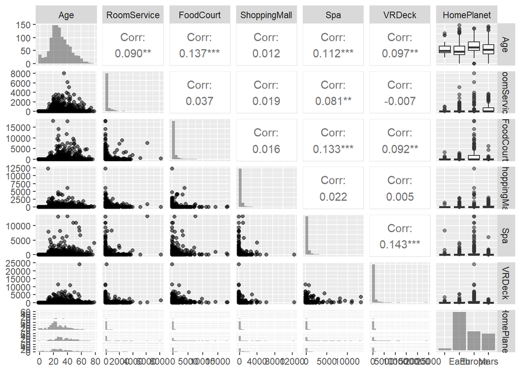

```r
ggpairs(cor_dt[c(num_names, "HomePlanet")], aes(alpha = 0.5),
        diag = list(continuous = wrap("barDiag", bins = 20)))
```

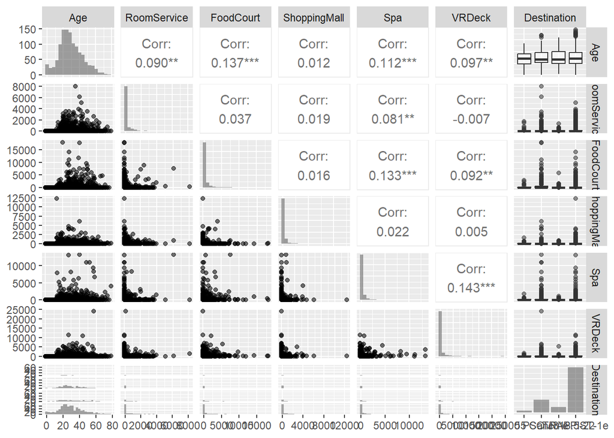

```r
ggpairs(cor_dt[c(num_names, "Destination")], aes(alpha = 0.5),
        diag = list(continuous = wrap("barDiag", bins = 20)))
```

```r
cor_dt_log<-cor_dt
cor_dt_log[num_names]<-log(cor_dt_log[num_names])
incor_dt_log<-incor_dt
incor_dt_log[num_names]<-log(incor_dt_log[num_names])
```

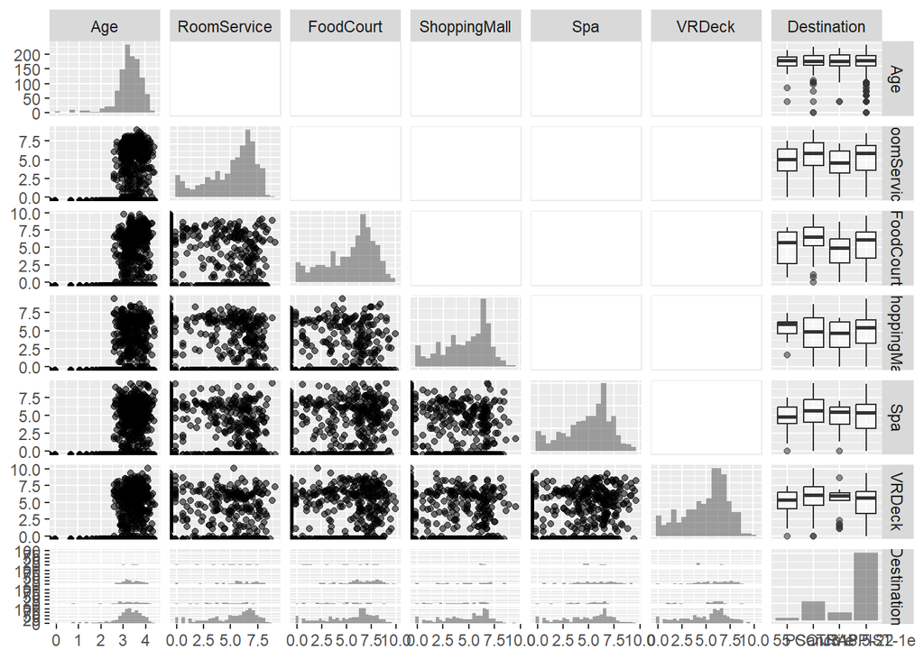

```r
ggpairs(cor_dt_log[c(num_names, "Destination")], aes(alpha = 0.5),
        diag = list(continuous = wrap("barDiag", bins = 20)))
```

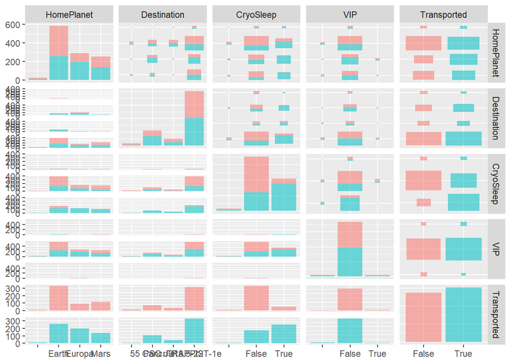

```r
ggpairs(cor_dt[c("HomePlanet", "Destination", "CryoSleep", "VIP", "Transported")], aes(color=Transported, alpha=0.5), diag = list(continuous = wrap("barDiag", bins = 20)))
```

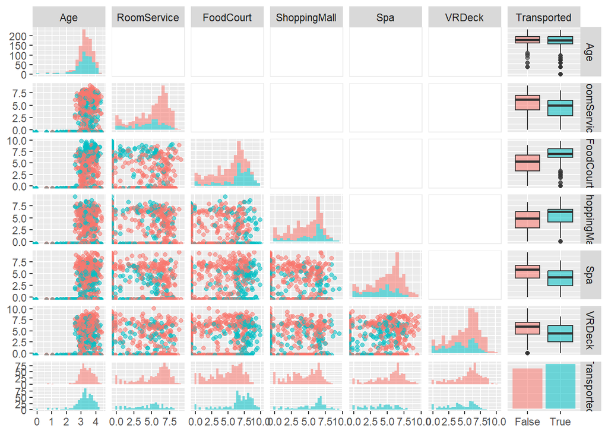

```r
ggpairs(cor_dt_log[c(num_names, "Transported")], aes(color=Transported, alpha=0.5), diag = list(continuous = wrap("barDiag", bins = 20)))
```

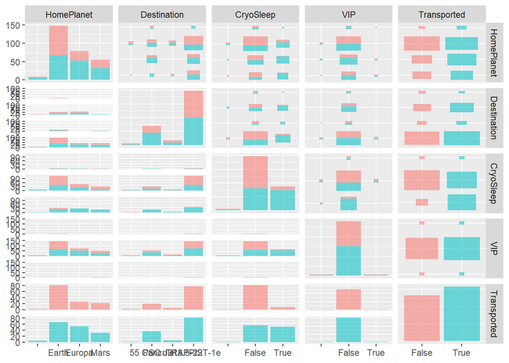

```r
ggpairs(incor_dt[c("HomePlanet", "Destination", "CryoSleep", "VIP", "Transported")], aes(color=Transported, alpha=0.5), diag = list(continuous = wrap("barDiag", bins = 20)))
```

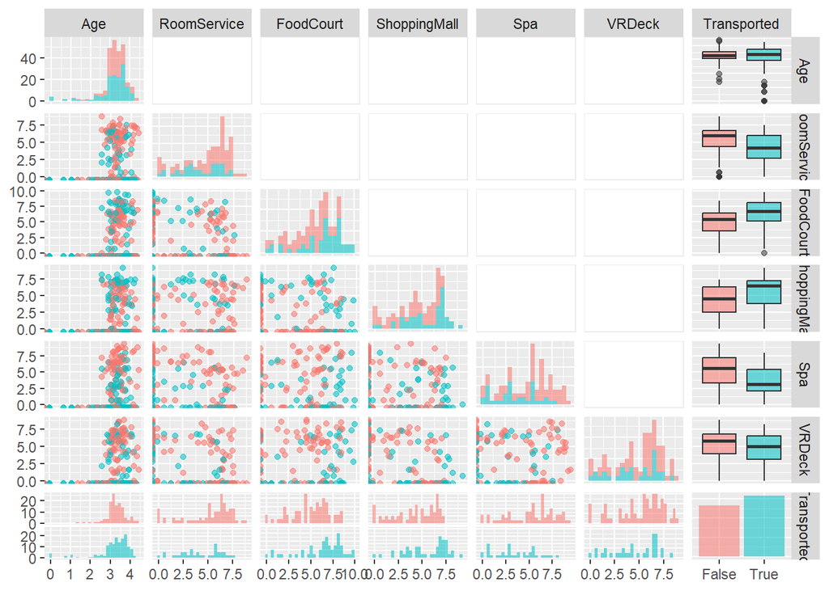

```r
ggpairs(incor_dt_log[c(num_names, "Transported")], aes(color=Transported, alpha=0.5), diag = list(continuous = wrap("barDiag", bins = 20)))
```

Из результатов можно заметить из cor_dt (обучаемая модель верно предсказала Transported), что CryoSleep влияет на Transported.

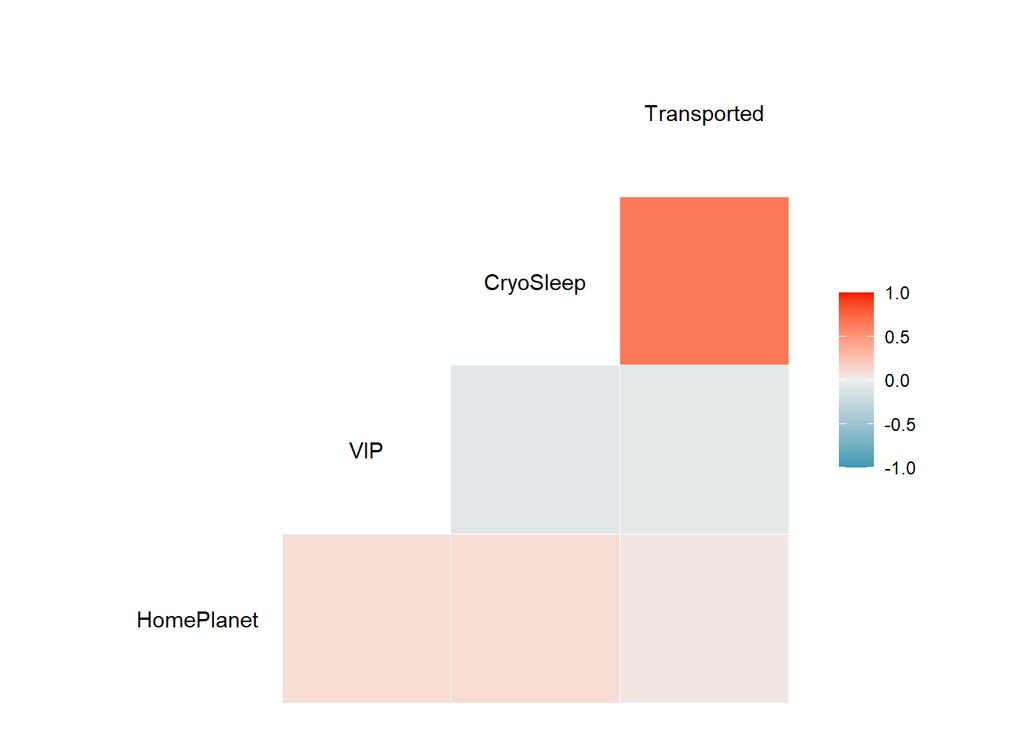

```r
cor_dt_mod<-dt_modified[cor_svm,]
cor_dt_mod$Transported<-as.integer(as.logical(cor_dt_mod$Transported))
ggcorr(cor_dt_mod[c("HomePlanet", "VIP", "CryoSleep", "Transported")])
```

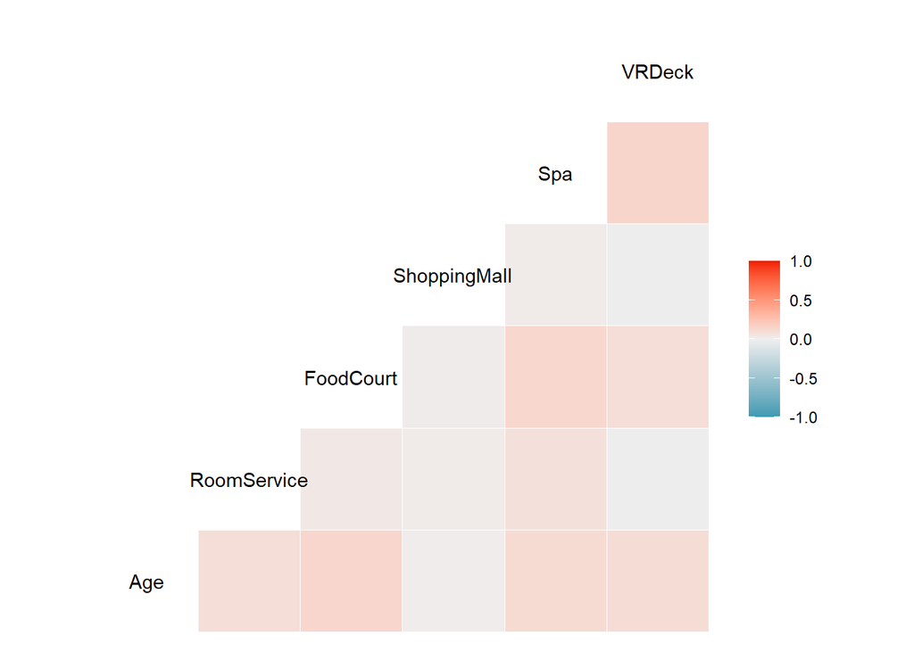

```r
ggcorr(cor_dt)
```

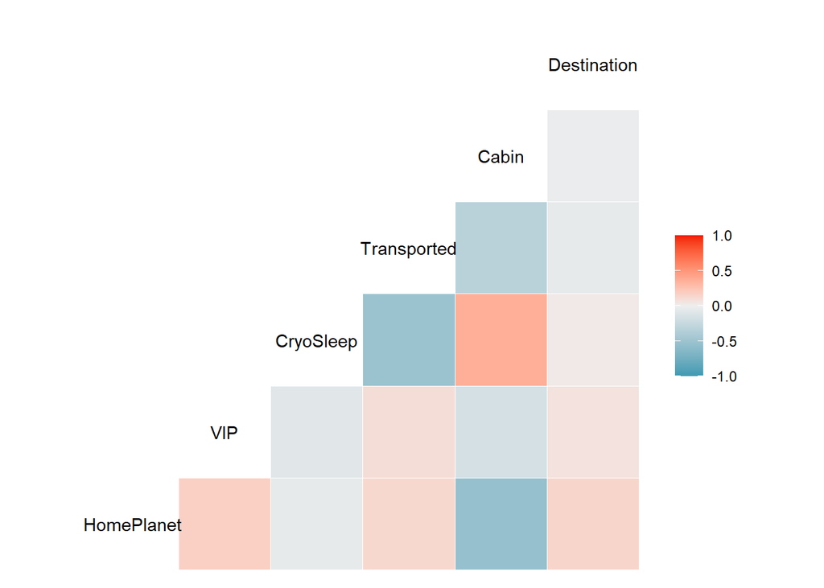

```r
incor_dt_mod<-dt_modified[incor_svm,]
incor_dt_mod$Transported<-as.integer(as.logical(incor_dt_mod$Transported))
ggcorr(incor_dt_mod[c("HomePlanet", "VIP", "CryoSleep", "Transported", "Cabin", "Destination")])
```

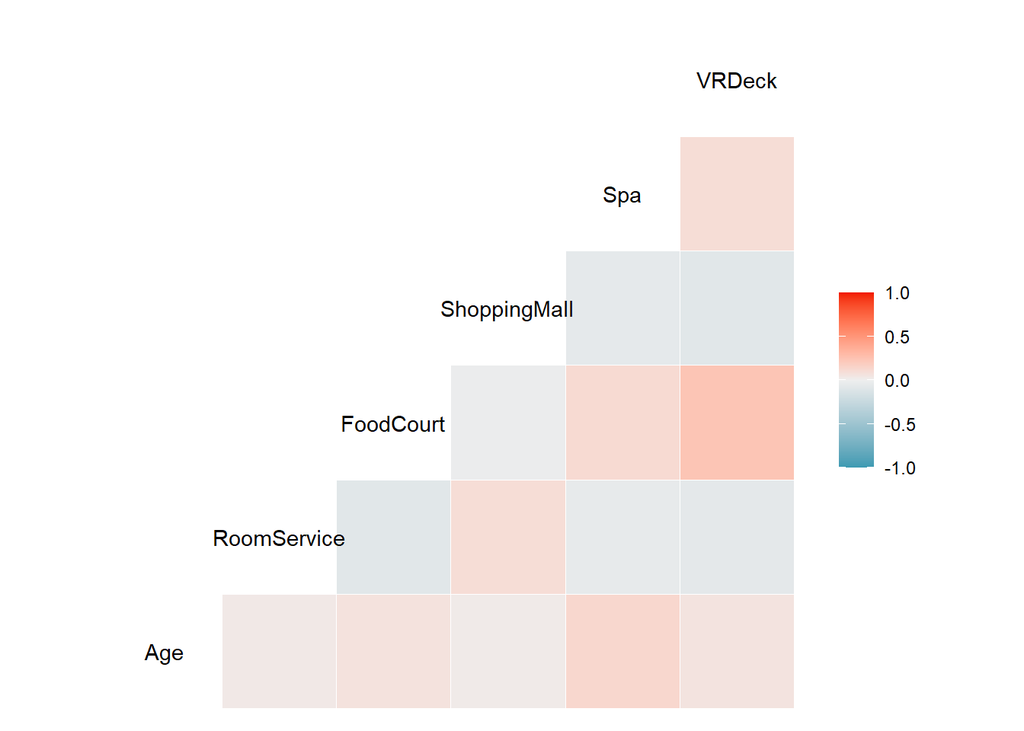

```r
ggcorr(incor_dt)
```